# Validating Driver Profiles

## Motivation

- Driving is a complex tasks humans do on a daily basis
- It involves
  - motor control (e.g., steering)
  - path finding (e.g., home to work)
  - attentional processes and object recognition
- Difficult to investigate these aspects on the real road
  - \(\Rightarrow\) **Driving simulators!**

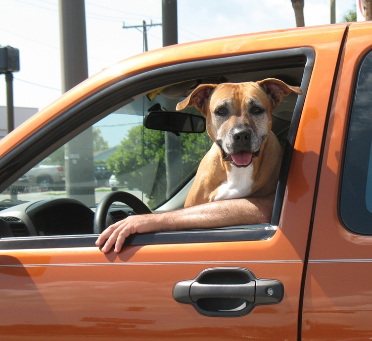

## Driving simulators

- [Show video] https://www.youtube.com/watch?v=A8UZVXq4R9k

## Driving simulators

- Driving simulators offer a variety of benefits:
  - controlled and standardized environment
  - ease of collecting high quality data (distance to other cars, reaction time, etc.)
  - can simulate dangerous situations without harming participants
  - provide a means to test novel user-interfaces and assistance systems
  - overall, have a high cost-effectiveness (Winter et al., 2009)

[figure not shown]

## Driving simulators

- Driving simulators are machines of extreme technical complexity (Schöner & Morys, 2015)
- Various aspects influence the **validity** of driving simulators
  - **Physical validity:** degree to which the simulator reproduces physical reality \(\checkmark\)
  - **Behavioural validity:** degree to which driving behaviour in simulator corresponds to real road \(\checkmark\)
  - Do the computer-simulated drivers behave like real humans? **Current question!**

[figure not shown]

## Modeling drivers

- There exist different approaches to modeling traffic (van Wageningen-Kessels et al., 2014)
  - Macroscopic traffic simulations
  - Microscopic traffic simulations
    - Specify certain parameters for the drivers (e.g., desired velocity)
- How do we calibrate the parameter values and model differences among drivers?

## Modeling drivers: Empirical basis

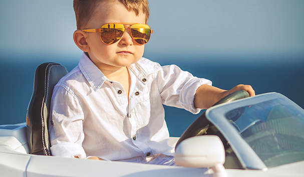

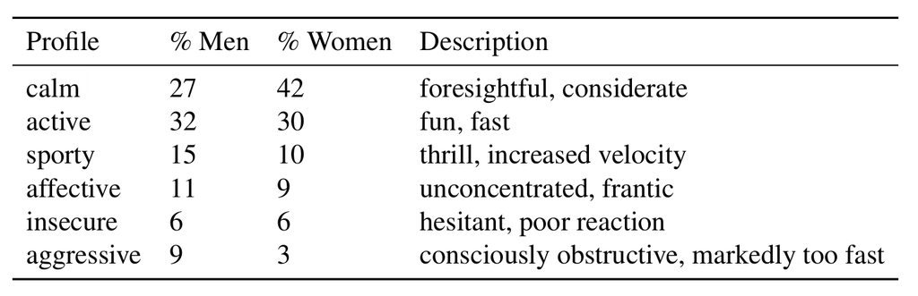

## Overview: Studies

- Try to answer two broad questions
  - **(a)** Can we recover the driver profiles based on simulated data? How similar are the profiles to each other?  
    **\(\Rightarrow\) Simulation-based study**
  - **(b)** Are the new driver profiles an improvement? In general, what do participants think about the traffic simulation?  
    **\(\Rightarrow\) Experimental study**

## Simulation-based study

## Setup

- For every driver profile: 50 data sets (75.9km) for low, medium, and high traffic density
- A data set consists of measurements of
  - **Speed**
  - **Headway**
  - **Acceleration**
  - **Number of lane changes**
  - **Total amount of time spent on each lane**
- This is a classification problem with several features  
  \(\Rightarrow\) Random forests!

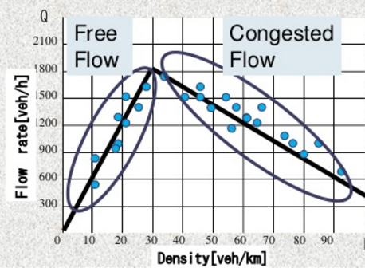

## Example: Speed

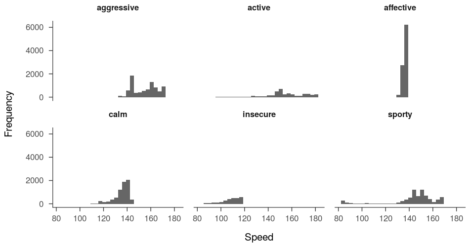

## Classification Trees

- To illustrate: short botanical excursion to the *Iris* data set (Fisher, 1936)

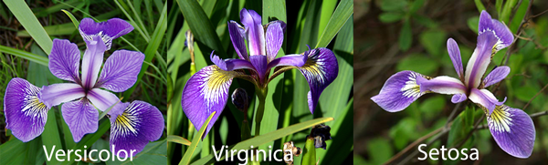

## Classification Trees

```r
data(iris)

head(iris, 10)
```

```
##    Sepal.Length Sepal.Width Petal.Length Petal.Width Species
## 1           5.1         3.5          1.4         0.2  setosa
## 2           4.9         3.0          1.4         0.2  setosa
## 3           4.7         3.2          1.3         0.2  setosa
## 4           4.6         3.1          1.5         0.2  setosa
## 5           5.0         3.6          1.4         0.2  setosa
## 6           5.4         3.9          1.7         0.4  setosa
## 7           4.6         3.4          1.4         0.3  setosa
## 8           5.0         3.4          1.5         0.2  setosa
## 9           4.4         2.9          1.4         0.2  setosa
## 10          4.9         3.1          1.5         0.1  setosa
```

## Classification Trees

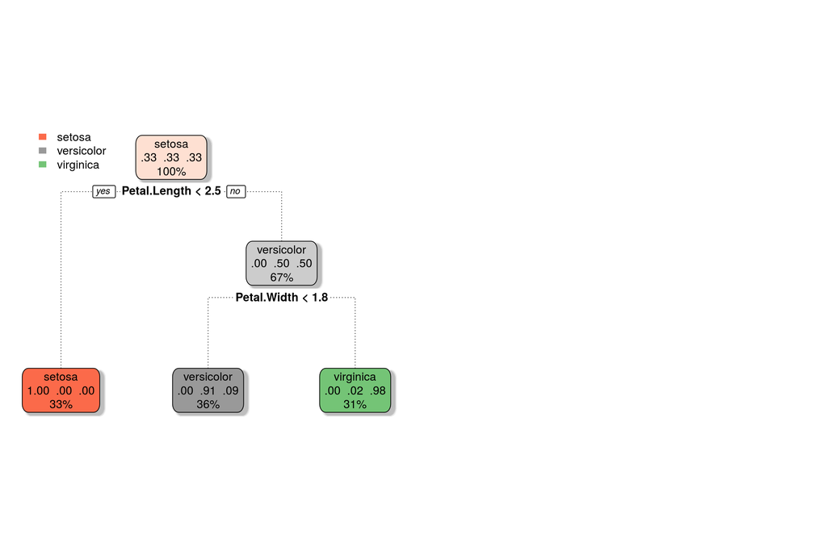

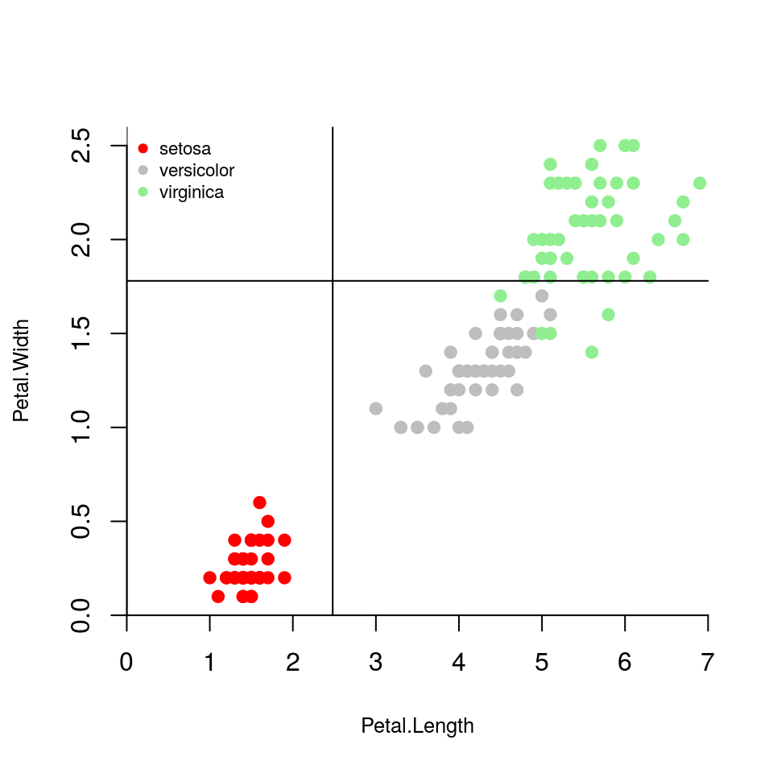

## Random Forests

- **Random Forest**
  - average over many classification trees (e.g., Strobl, Malley, Tutz, 2009)
  - also allow for clustering (Liaw & Wiener, 2002)

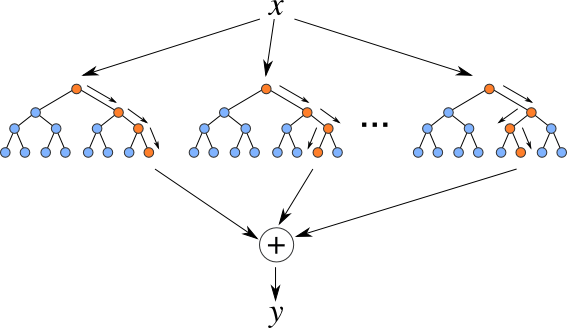

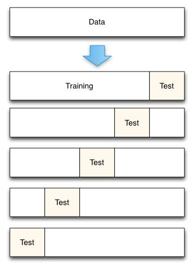

## Clustering: Low traffic density

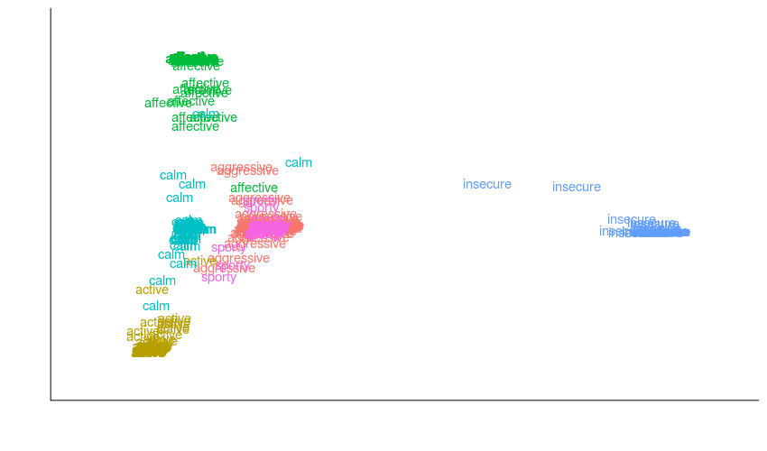

## Clustering: Medium traffic density

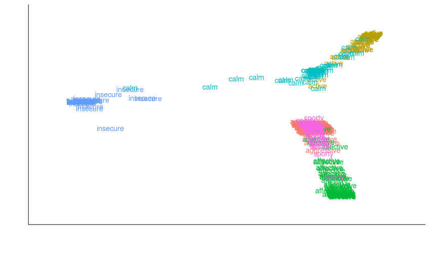

## Clustering: High traffic density

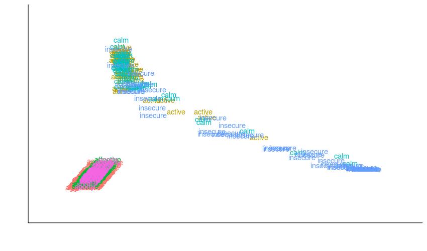

## Experimental Study

## Setup

- A previous version of the driving simulation did not model individual differences
  - I call this version the **"old"** version
- Experiment focused on the **aggressive** and **calm** driver profiles
  - Are they "better" than the previous version of drivers?
- \(32^{\star}\) participants took part in a driving simulator study at the FKFS in Stuttgart

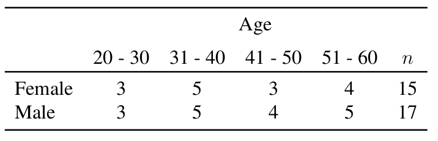

## Setup

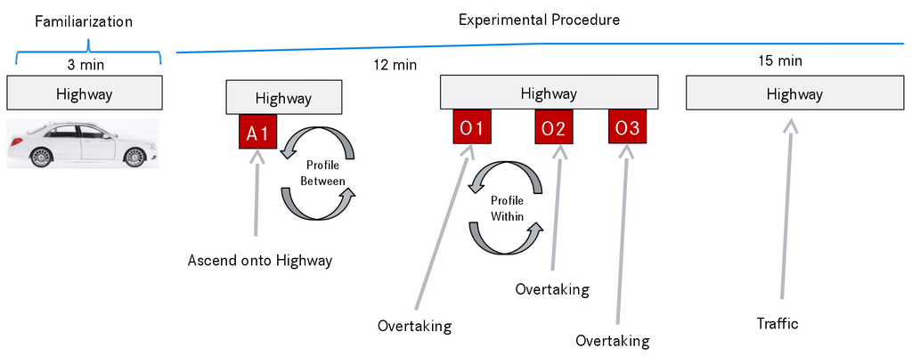

## Setup

- Quantitative part
  - Instruction: Cars either being driven by a human or a computer
  - Two questions after each scenario
    - Was the driver a human or a computer? (0, 1)
    - How realistic was the driving behaviour? (1 - 7)
    - [Simulator sickness]
- Qualitative part:
  - free driving
  - subjects were instructed to *think aloud* and comment on what's happening

## Hypotheses

- In comparison to the **old** driver profiles, the behaviour of **aggressive** and **calm** drivers should be
  - judged more frequently as being human (0, 1)
  - judged as being more realistic (1 - 7)
- These are *directed* hypotheses
- Note also that they are only with respect to overtaking on a high-way

## Raw data: Human or Computer

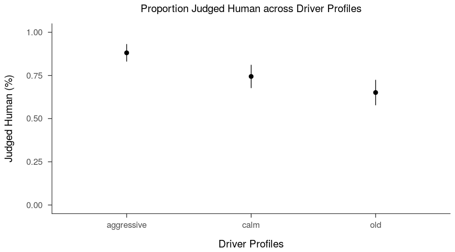

## Raw data: Realism judgements

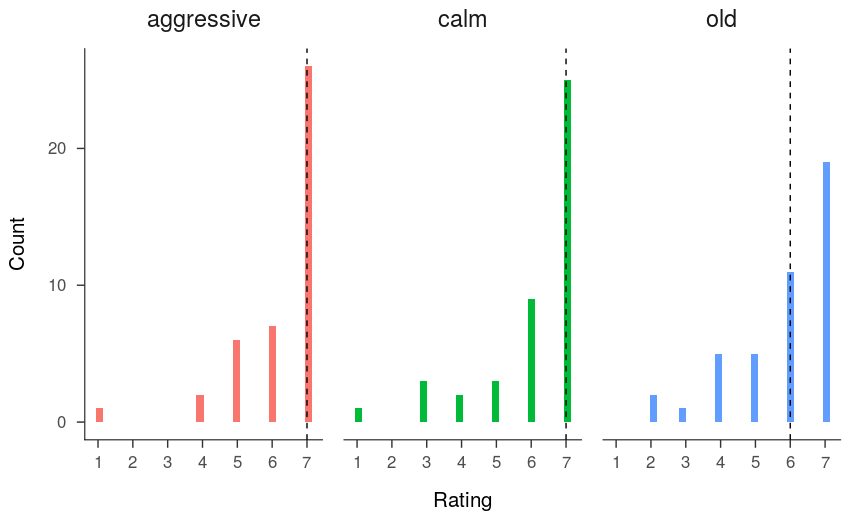

## Analysis

- Used Bayesian logistic and ordinal regression models to analyze the data
- Computed Bayes factors as a continuous measure of evidence (e.g., Morey, Romejin, & Rouder, 2013)

\[ \begin{align*} \underbrace{\frac{p(\mathcal{M}_1 \mid y)}{p(\mathcal{M}_0 \mid y)}}_{\text{Posterior Odds}} = \underbrace{\frac{p(y \mid \mathcal{M}_1)}{p(y \mid \mathcal{M}_0)}}_{\text{Bayes Factor}} \times \underbrace{\frac{p(\mathcal{M}_1)}{p(\mathcal{M}_0)}}_{\text{Prior Odds}} \end{align*} \]

- Requires computing the integral \(p(y \mid \mathcal{M}) = \int_{\Theta} p(y \mid \mathcal{M}, \theta) p(\theta \mid \mathcal{M})\theta\)
- Can all be done in *brms*!

## Model comparison: Results

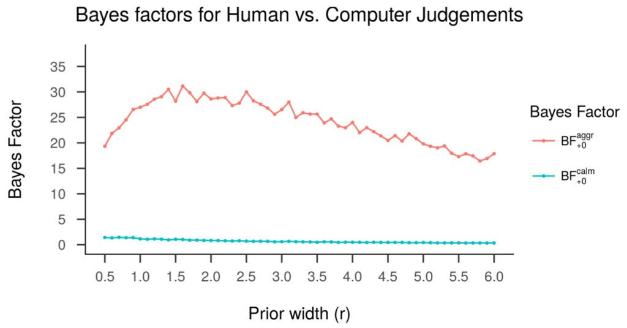

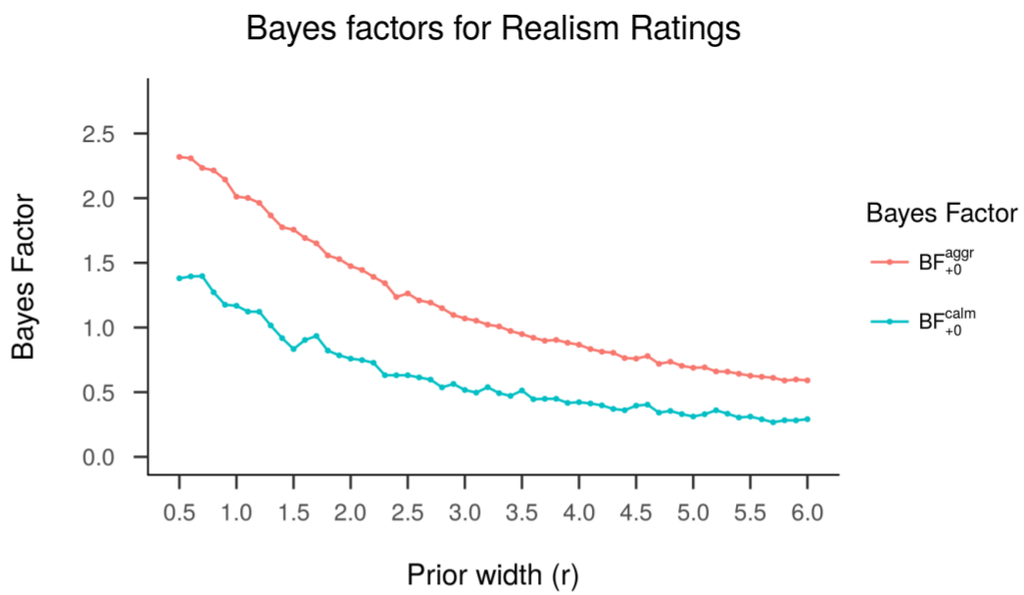

## Qualitative Part

- 15 minutes of free driving, *think aloud* protocol
- Points of improvement
  - cars drove in their lanes too perfectly
  - headway to the participant and each other was unrealistically large
  - no critical occurances
  - drivers used the indicator too frequently
  - trucks rarely overtook each other
  - pull to drive on the right lane was too strong, resulted in unrealistic overtaking

## Conclusion

- **Aggressive** driver profile is perceived as more human-like than **old** profiles
  - Most likely due to the increased speed of the aggressive driver ("computer would follow norms")
- Some Issues
  - Experimental design incorporated no ground truth
  - Comparisons are very situation-specific
  - Participants received very little information about the other drivers
  - *Realism* is certainly not unidimensional, high variance in its interpretation
  - What, in a modern car, is the difference between a human and a computer driver?
- Different experimental designs probably more appealing
  - Videos of certain situations shown with all driver profiles
  - Participants have to rate which profile is most likely given the behaviour displayed

## Materials

- All materials available from https://osf.io/dw5hr/
  - Includes all data, analysis code, slides, thesis manuscript
  - Includes also an appendix on "Some Issues in Psychological Science"
    - Written for applied researchers, provides an
      - overview of the replication crisis
      - an introduction to Bayesian statistics
      - and three practical recommendations for applied research

## Thanks for your attention!

## Appendix

## Agent Simulation: Implementation (Detail)

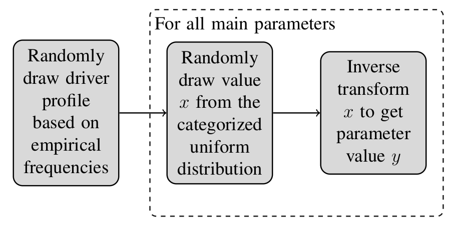

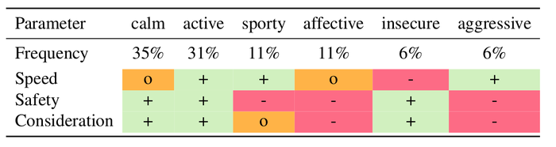

## Agent Simulation: Implementation (Detail)

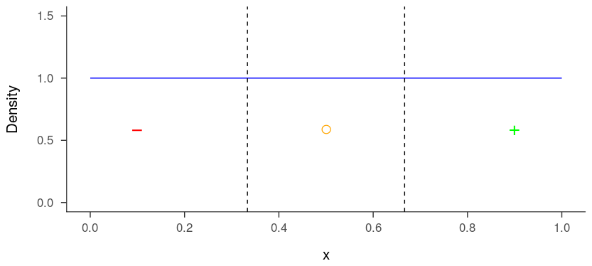

## Agent Simulation: Implementation (Detail)

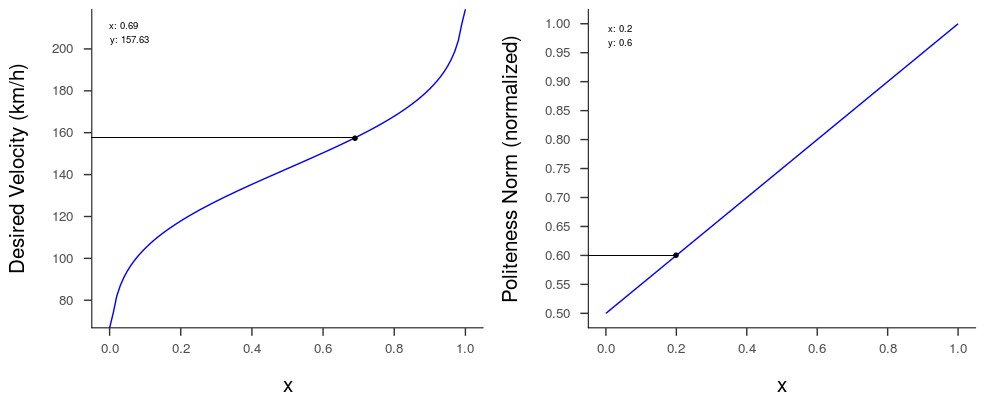

## Agent Simulation: Implementation (Detail)

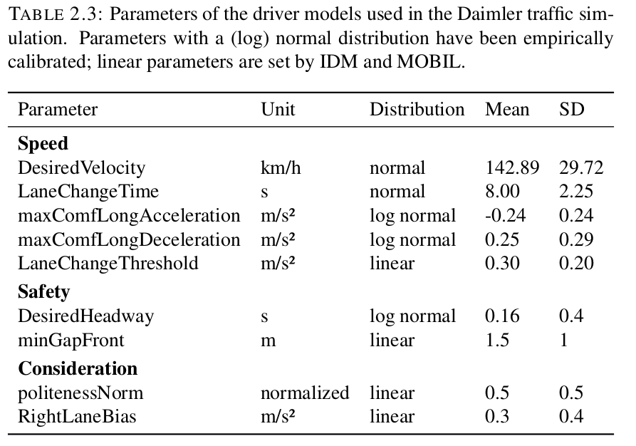

## What Parameters did you use in Random Forest?

- Random Forests have two parameters
  - number of trees (selected 2000)
  - number of predictors randomly sampled (default: \(\sqrt{p}\))
- Random Forests are generally robust w.r.t the specification (Liaw & Wiener, 2002)